# Practice 9.2: Multiclass

Our dataset consists of clinical data from patients who entered the hospital complaining of chest pain (“angina”) during exercise. The information collected includes:

- `age` : Age of the patient
- `sex` : Sex of the patient
- `cp` : Chest Pain type
  - Value 0: asymptomatic
  - Value 1: typical angina
  - Value 2: atypical angina
  - Value 3: non-anginal pain
- `trtbps` : resting blood pressure (in mm Hg)
- `chol` : cholesterol in mg/dl fetched via BMI sensor
- `restecg` : resting electrocardiographic results
  - Value 0: normal
  - Value 1: having ST-T wave abnormality (T wave inversions and/or ST elevation or depression of > 0.05 mV)
  - Value 2: showing probable or definite left ventricular hypertrophy by Estes’ criteria
- `thalach` : maximum heart rate achieved during exercise
- `output` : the doctor’s diagnosis of whether the patient is at risk for a heart attack
  - 0 = not at risk of heart attack
  - 1 = at risk of heart attack

```python
## library imports here
import pandas as pd
from sklearn.pipeline import Pipeline
from sklearn.neighbors import KNeighborsClassifier
from sklearn.tree import DecisionTreeClassifier
from sklearn.linear_model import LogisticRegression
from sklearn.compose import ColumnTransformer, make_column_selector
from sklearn.preprocessing import OneHotEncoder, StandardScaler
from sklearn.model_selection import GridSearchCV
from sklearn.tree import plot_tree
import numpy as np
import matplotlib.pyplot as plt
from sklearn.discriminant_analysis import LinearDiscriminantAnalysis
```

```python
ha = pd.read_csv("https://www.dropbox.com/s/aohbr6yb9ifmc8w/heart_attack.csv?dl=1")
```

```python
ha.head()
```

|  | age | sex | cp | trtbps | chol | restecg | thalach | output |
| --- | --- | --- | --- | --- | --- | --- | --- | --- |
| 0 | 63 | 1 | 3 | 145 | 233 | 0 | 150 | 1 |
| 1 | 37 | 1 | 2 | 130 | 250 | 1 | 187 | 1 |
| 2 | 56 | 1 | 1 | 120 | 236 | 1 | 178 | 1 |
| 3 | 57 | 0 | 0 | 120 | 354 | 1 | 163 | 1 |
| 4 | 57 | 1 | 0 | 140 | 192 | 1 | 148 | 1 |

```python
# When I column transform chest pain and other categorical
# variables represented as numbers, I don't want to have
# to deal with interpretting the 1's, 2's and so on, I'd rather
# just interpret as is, so I'm transforming.

# Chest Pain Transformer
def output(x):
    if x == 0:
        return "NoRisk"
    else:
        return "Risk"

# Resting Electrocardiographic Results
def restecg(x):
    if x == 0:
        return "Normal"
    elif x == 1:
        return "STTWaveAbnormal"
    else:
        return "LeftVentHypertrophy"

# Sex
def sex(x):
    if x == 1:
        return "Male"
    else:
        return "Female"

# Chest Pain Transformer
def chest_pain(x):
    if x == 1:
        return "TypicalAngina"
    elif x == 2:
        return "AtypicalAngina"
    elif x == 3:
        return "NonAnginalPain"
    else:
        return "Asymptomatic"


ha["restecg"] = ha["restecg"].apply(restecg)
ha["sex"] = ha["sex"].apply(sex)
ha["output"] = ha["output"].apply(output)
ha["cp"] = ha["cp"].apply(chest_pain)
```

## Q1: Natural Multiclass Models

Fit a multiclass KNN, Decision Tree, and LDA for the heart disease data; this time predicting the type of chest pain (categories 0 - 3) that a patient experiences. For the decision tree, plot the fitted tree, and interpret the first couple splits.

```python
X = ha.drop(columns=["cp"])
y = ha["cp"]
```

```python
def buildColTransformer():
    """
    Constructs a default column transformer for encoding categorical vars
    and scaling numeric vars

    Parameters
    ----------
    None

    Returns
    -------
    ct : sklearn ColumnTransformer
        ct object ready to be used in a sklearn Pipeline


    """
    enc = OneHotEncoder(sparse_output=False, handle_unknown="ignore")
    scaler = StandardScaler()
    get_categoric = make_column_selector(dtype_include=object)
    get_numeric = make_column_selector(dtype_include=np.number)

    ct = ColumnTransformer([
        ("dummify", enc, get_categoric),
        ("standardize", scaler, get_numeric)
    ], remainder="passthrough").set_output(transform="pandas")

    return ct
```

```python
knn = KNeighborsClassifier()

ct = buildColTransformer()

my_pipeline = Pipeline(
        [("preprocessing", ct),
        ("model", knn)]
).set_output(transform = "pandas")

search_dict = {"model__n_neighbors" : np.arange(1,100,2)}

grid_pipeline = GridSearchCV(my_pipeline, search_dict, cv=5, scoring="accuracy")
grid_results = grid_pipeline.fit(X, y)
search_dict_keys = [f"param_{item}" for item in search_dict.keys()]
search_dict_keys.append("mean_test_score")
grid_df = pd.DataFrame(grid_results.cv_results_)[search_dict_keys]
grid_df["mean_test_score"] = abs(grid_df["mean_test_score"])
grid_df = grid_df.sort_values(by=["mean_test_score"], ascending=False).head().reset_index(drop=True)
grid_df
```

|  | param_model__n_neighbors | mean_test_score |
| --- | --- | --- |
| 0 | 25 | 0.556835 |
| 1 | 23 | 0.549495 |
| 2 | 9 | 0.542222 |
| 3 | 21 | 0.542155 |
| 4 | 19 | 0.538586 |

```python
dt = DecisionTreeClassifier()

ct = buildColTransformer()

my_pipeline = Pipeline(
        [("preprocessing", ct),
        ("model", dt)]
).set_output(transform = "pandas")

search_dict = {
    "model__ccp_alpha" : [0, 0.001, 0.01, 0.1],
    "model__max_depth" : [None, 50, 60, 65, 70],
    "model__min_samples_leaf" : [25, 35, 45]
}
grid_pipeline = GridSearchCV(my_pipeline, search_dict, cv=5, scoring="accuracy")
grid_results = grid_pipeline.fit(X, y)
search_dict_keys = [f"param_{item}" for item in search_dict.keys()]
search_dict_keys.append("mean_test_score")
grid_df = pd.DataFrame(grid_results.cv_results_)[search_dict_keys]
grid_df["mean_test_score"] = abs(grid_df["mean_test_score"])
grid_df = grid_df.sort_values(by=["mean_test_score"], ascending=False).head().reset_index(drop=True)
grid_df
```

|  | param_model__ccp_alpha | param_model__max_depth | param_model__min_samples_leaf | mean_test_score |
| --- | --- | --- | --- | --- |
| 0 | 0.01 | None | 25 | 0.552997 |
| 1 | 0.01 | 65 | 35 | 0.552997 |
| 2 | 0.01 | 50 | 25 | 0.552997 |
| 3 | 0.01 | None | 35 | 0.552997 |
| 4 | 0 | None | 35 | 0.552997 |

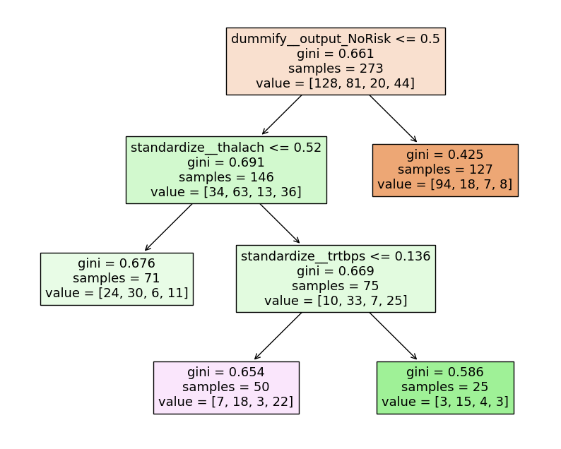

```python
final_dt = DecisionTreeClassifier(ccp_alpha=0.01, max_depth=None, min_samples_leaf=25)

my_pipeline = Pipeline(
        [("preprocessing", ct),
        ("model", final_dt)]
).set_output(transform = "pandas")


fitted_pipeline = my_pipeline.fit(X, y)
feature_names = ct.fit_transform(X).columns

plt.figure(figsize=(10,8))
plot_tree(fitted_pipeline["model"], feature_names=feature_names, filled=True)

plt.show()
```

```python
lda = LinearDiscriminantAnalysis()

ct = buildColTransformer()

my_pipeline = Pipeline(
        [("preprocessing", ct),
        ("model", lda)]
).set_output(transform = "pandas")

search_dict = {
    "model__solver" : ["svd", "lsqr"]
}

grid_pipeline = GridSearchCV(my_pipeline, search_dict, cv=5, scoring="accuracy")
grid_results = grid_pipeline.fit(X, y)
search_dict_keys = [f"param_{item}" for item in search_dict.keys()]
search_dict_keys.append("mean_test_score")
grid_df = pd.DataFrame(grid_results.cv_results_)[search_dict_keys]
grid_df["mean_test_score"] = abs(grid_df["mean_test_score"])
grid_df = grid_df.sort_values(by=["mean_test_score"], ascending=False).head().reset_index(drop=True)
grid_df
```

|  | param_model__solver | mean_test_score |
| --- | --- | --- |
| 0 | svd | 0.531246 |
| 1 | lsqr | 0.531246 |

## Q2: OvR

Create a new column in the `ha` dataset called `cp_is_3`, which is equal to `1` if the `cp` variable is equal to `3` and `0` otherwise.

Then, fit a Logistic Regression to predict this new target, and report the **F1 Score**.

Repeat for the other three `cp` categories. Which category was the OvR approach best at distinguishing?

```python
ha.head()
```

|  | age | sex | cp | trtbps | chol | restecg | thalach | output |
| --- | --- | --- | --- | --- | --- | --- | --- | --- |
| 0 | 63 | Male | NonAnginalPain | 145 | 233 | Normal | 150 | Risk |
| 1 | 37 | Male | AtypicalAngina | 130 | 250 | STTWaveAbnormal | 187 | Risk |
| 2 | 56 | Male | TypicalAngina | 120 | 236 | STTWaveAbnormal | 178 | Risk |
| 3 | 57 | Female | Asymptomatic | 120 | 354 | STTWaveAbnormal | 163 | Risk |
| 4 | 57 | Male | Asymptomatic | 140 | 192 | STTWaveAbnormal | 148 | Risk |

```python
def chest_pain(x):
    if x == 1:
        return "TypicalAngina"
    elif x == 2:
        return "AtypicalAngina"
    elif x == 3:
        return "NonAnginalPain"
    else:
        return "Asymptomatic"

def cp_is_3(x):
    if x == "NonAnginalPain":
      return 1
    else:
      return 0

def cp_is_2(x):
    if x == "AtypicalAngina":
      return 1
    else:
      return 0

def cp_is_1(x):
    if x == "TypicalAngina":
      return 1
    else:
      return 0

def cp_is_0(x):
    if x == "Asymptomatic":
      return 1
    else:
      return 0

ha["cp_is_3"] = ha["cp"].apply(cp_is_3)
ha["cp_is_2"] = ha["cp"].apply(cp_is_2)
ha["cp_is_1"] = ha["cp"].apply(cp_is_1)
ha["cp_is_0"] = ha["cp"].apply(cp_is_0)
```

```python
X = ha.drop(columns=["cp_is_3", "cp", "cp_is_2", "cp_is_1", "cp_is_0"])
y = ha["cp_is_3"]

logistic = LogisticRegression()

ct = buildColTransformer()

my_pipeline = Pipeline(
        [("preprocessing", ct),
        ("model", logistic)]
).set_output(transform = "pandas")

search_dict = {"model__penalty" : ["l2"]}

grid_pipeline = GridSearchCV(my_pipeline, search_dict, cv=5, scoring="f1")
grid_results = grid_pipeline.fit(X, y)
search_dict_keys = [f"param_{item}" for item in search_dict.keys()]
search_dict_keys.append("mean_test_score")
grid_df = pd.DataFrame(grid_results.cv_results_)[search_dict_keys]
grid_df["mean_test_score"] = abs(grid_df["mean_test_score"])
grid_df = grid_df.sort_values(by=["mean_test_score"], ascending=False).head().reset_index(drop=True)
grid_df
```

|  | param_model__penalty | mean_test_score |
| --- | --- | --- |
| 0 | l2 | 0.0 |

```python
X = ha.drop(columns=["cp_is_3", "cp", "cp_is_2", "cp_is_1", "cp_is_0"])
y = ha["cp_is_2"]

logistic = LogisticRegression()

ct = buildColTransformer()

my_pipeline = Pipeline(
        [("preprocessing", ct),
        ("model", logistic)]
).set_output(transform = "pandas")

search_dict = {"model__penalty" : ["l2"]}

grid_pipeline = GridSearchCV(my_pipeline, search_dict, cv=5, scoring="f1")
grid_results = grid_pipeline.fit(X, y)
search_dict_keys = [f"param_{item}" for item in search_dict.keys()]
search_dict_keys.append("mean_test_score")
grid_df = pd.DataFrame(grid_results.cv_results_)[search_dict_keys]
grid_df["mean_test_score"] = abs(grid_df["mean_test_score"])
grid_df = grid_df.sort_values(by=["mean_test_score"], ascending=False).head().reset_index(drop=True)
grid_df
```

|  | param_model__penalty | mean_test_score |
| --- | --- | --- |
| 0 | l2 | 0.137255 |

```python
X = ha.drop(columns=["cp_is_3", "cp", "cp_is_2", "cp_is_1", "cp_is_0"])
y = ha["cp_is_1"]

logistic = LogisticRegression()

ct = buildColTransformer()

my_pipeline = Pipeline(
        [("preprocessing", ct),
        ("model", logistic)]
).set_output(transform = "pandas")

search_dict = {"model__penalty" : ["l2"]}

grid_pipeline = GridSearchCV(my_pipeline, search_dict, cv=5, scoring="f1")
grid_results = grid_pipeline.fit(X, y)
search_dict_keys = [f"param_{item}" for item in search_dict.keys()]
search_dict_keys.append("mean_test_score")
grid_df = pd.DataFrame(grid_results.cv_results_)[search_dict_keys]
grid_df["mean_test_score"] = abs(grid_df["mean_test_score"])
grid_df = grid_df.sort_values(by=["mean_test_score"], ascending=False).head().reset_index(drop=True)
grid_df
```

|  | param_model__penalty | mean_test_score |
| --- | --- | --- |
| 0 | l2 | 0.0 |

```python
X = ha.drop(columns=["cp_is_3", "cp", "cp_is_2", "cp_is_1", "cp_is_0"])
y = ha["cp_is_0"]

logistic = LogisticRegression()

ct = buildColTransformer()

my_pipeline = Pipeline(
        [("preprocessing", ct),
        ("model", logistic)]
).set_output(transform = "pandas")

search_dict = {"model__penalty" : ["l2"]}

grid_pipeline = GridSearchCV(my_pipeline, search_dict, cv=5, scoring="f1")
grid_results = grid_pipeline.fit(X, y)
search_dict_keys = [f"param_{item}" for item in search_dict.keys()]
search_dict_keys.append("mean_test_score")
grid_df = pd.DataFrame(grid_results.cv_results_)[search_dict_keys]
grid_df["mean_test_score"] = abs(grid_df["mean_test_score"])
grid_df = grid_df.sort_values(by=["mean_test_score"], ascending=False).head().reset_index(drop=True)
grid_df
```

|  | param_model__penalty | mean_test_score |
| --- | --- | --- |
| 0 | l2 | 0.649258 |

## OvR was the best at distinguishing category 0, asymptomatic.

## Q3: OvO

Reduce your dataset to only the `0` and `1` types of chest pain.

Then, fit a Logistic Regression to predict between the two groups, and report the **ROC-AUC**.

Repeat comparing category `0` to `2` and `3`. Which pair was the OvO approach best at distinguishing?

```python
new = ha[(ha["cp_is_0"] == 1) | (ha["cp_is_1"] == 1)]
new.drop(columns=["cp_is_3", "cp_is_2"])

X = new.drop(columns=["cp_is_0", "cp_is_1", "cp"])
y = new["cp"]

logistic = LogisticRegression()

ct = buildColTransformer()

my_pipeline = Pipeline(
        [("preprocessing", ct),
        ("model", logistic)]
).set_output(transform = "pandas")

search_dict = {"model__penalty" : ["l2"]}

grid_pipeline = GridSearchCV(my_pipeline, search_dict, cv=5, scoring="roc_auc")
grid_results = grid_pipeline.fit(X, y)
search_dict_keys = [f"param_{item}" for item in search_dict.keys()]
search_dict_keys.append("mean_test_score")
grid_df = pd.DataFrame(grid_results.cv_results_)[search_dict_keys]
grid_df["mean_test_score"] = abs(grid_df["mean_test_score"])
grid_df = grid_df.sort_values(by=["mean_test_score"], ascending=False).head().reset_index(drop=True)
grid_df
```

|  | param_model__penalty | mean_test_score |
| --- | --- | --- |
| 0 | l2 | 0.838927 |

```python
new = ha[(ha["cp_is_0"] == 1) | (ha["cp_is_2"] == 1)]
new.drop(columns=["cp_is_3", "cp_is_1"])

X = new.drop(columns=["cp_is_0", "cp_is_2", "cp"])
y = new["cp"]

logistic = LogisticRegression()

ct = buildColTransformer()

my_pipeline = Pipeline(
        [("preprocessing", ct),
        ("model", logistic)]
).set_output(transform = "pandas")

search_dict = {"model__penalty" : ["l2"]}

grid_pipeline = GridSearchCV(my_pipeline, search_dict, cv=5, scoring="roc_auc")
grid_results = grid_pipeline.fit(X, y)
search_dict_keys = [f"param_{item}" for item in search_dict.keys()]
search_dict_keys.append("mean_test_score")
grid_df = pd.DataFrame(grid_results.cv_results_)[search_dict_keys]
grid_df["mean_test_score"] = abs(grid_df["mean_test_score"])
grid_df = grid_df.sort_values(by=["mean_test_score"], ascending=False).head().reset_index(drop=True)
grid_df
```

|  | param_model__penalty | mean_test_score |
| --- | --- | --- |
| 0 | l2 | 0.745734 |

```python
new = ha[(ha["cp_is_0"] == 1) | (ha["cp_is_3"] == 1)]
new.drop(columns=["cp_is_2", "cp_is_1"])

X = new.drop(columns=["cp_is_0", "cp_is_3", "cp"])
y = new["cp"]

logistic = LogisticRegression()

ct = buildColTransformer()

my_pipeline = Pipeline(
        [("preprocessing", ct),
        ("model", logistic)]
).set_output(transform = "pandas")

search_dict = {"model__penalty" : ["l2"]}

grid_pipeline = GridSearchCV(my_pipeline, search_dict, cv=5, scoring="roc_auc")
grid_results = grid_pipeline.fit(X, y)
search_dict_keys = [f"param_{item}" for item in search_dict.keys()]
search_dict_keys.append("mean_test_score")
grid_df = pd.DataFrame(grid_results.cv_results_)[search_dict_keys]
grid_df["mean_test_score"] = abs(grid_df["mean_test_score"])
grid_df = grid_df.sort_values(by=["mean_test_score"], ascending=False).head().reset_index(drop=True)
grid_df
```

|  | param_model__penalty | mean_test_score |
| --- | --- | --- |
| 0 | l2 | 0.731308 |